# Homework 3

aa2569@scarletmail.rutgers.edu

9/26/2022

## Time Series - Cafe (fpp)

- The time series from fpp package shows the time series values of quarterly expenditure on cafes, restaurants and takeaway food services in Australia.
- The data shows the values from Qtr2 of 1982 to Qtr4 of 2010.
- The units of the values given have not been mentioned. By looking at the data, assuming the data to be in million dollars.

## Plotting the Time Series

```r
library(fpp)
```

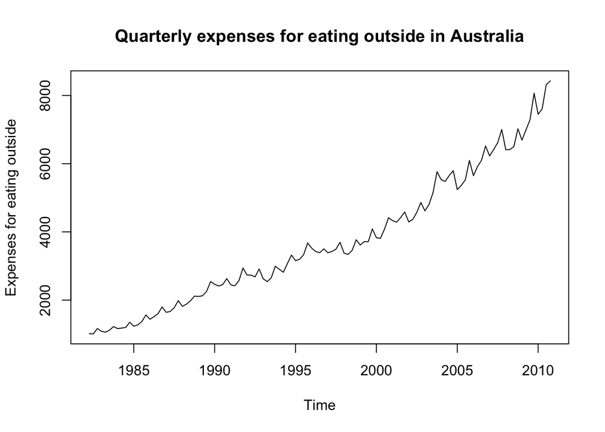

```r
plot(cafe,main = "Quarterly expenses for eating outside in Australia", xlab = "Time", ylab="Expenses for eating outside")
```

## ACF Plot

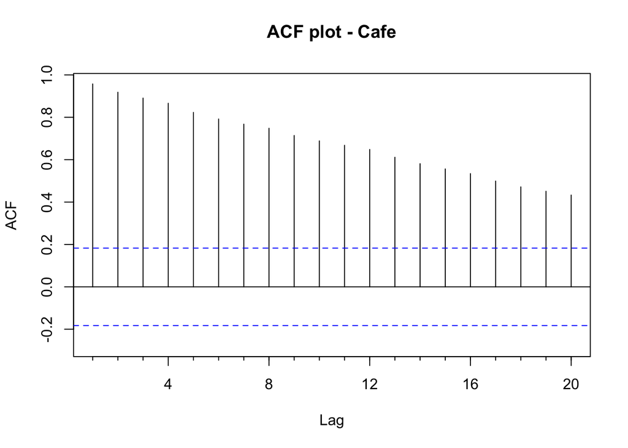

```r
Acf(cafe, main = "ACF plot - Cafe")
```

- The ACF plot shows all the correlation values above the 95% confidence interval.
- This shows that the historic data has significant impact on the preceding data.
- The predicted seasonality is not clearly visible in the ACF plot.
- A very slight wave nature can be seen, but is not so clear. So, our prediction of the data showing seasonality cannot be justified.

## PACF Plot

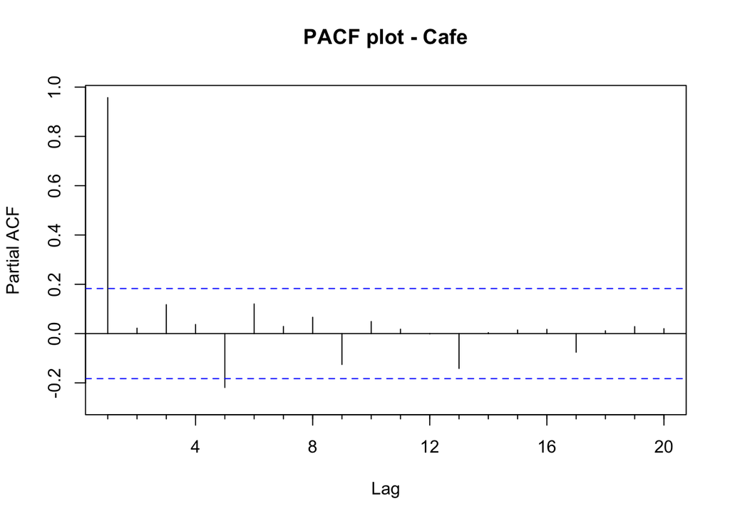

```r
Pacf(cafe, main = "PACF plot - Cafe")
```

- The PACF plot shows two lines crossing the significance line.
- By the above two inputs of ACF and PACF, we can conclude that we need to use AR(2) model for forecasting the trend.

## Holt-Winters Filtering

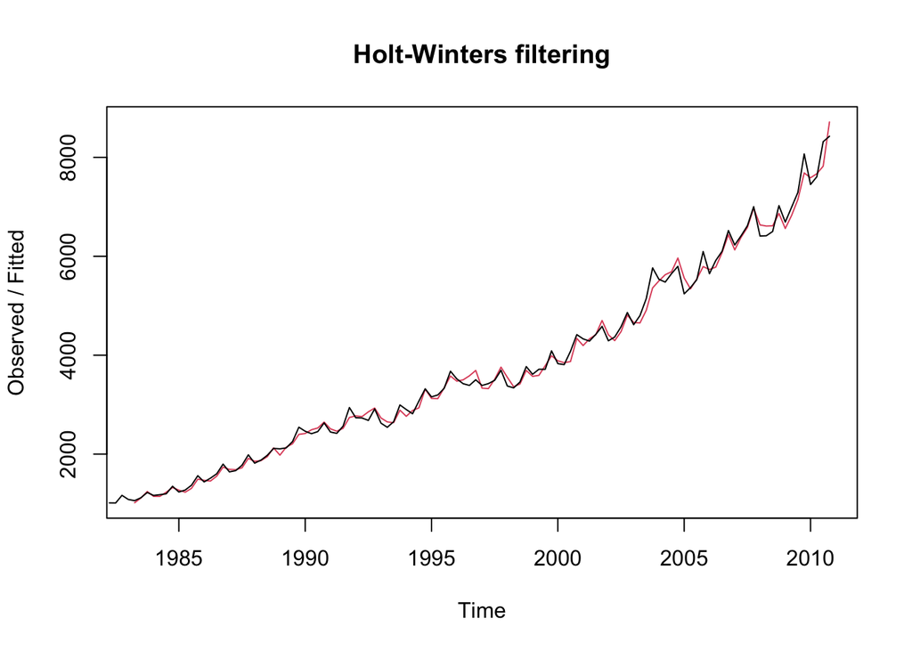

```r
cafe_hw1 <- HoltWinters(cafe)
plot(cafe_hw1)
```

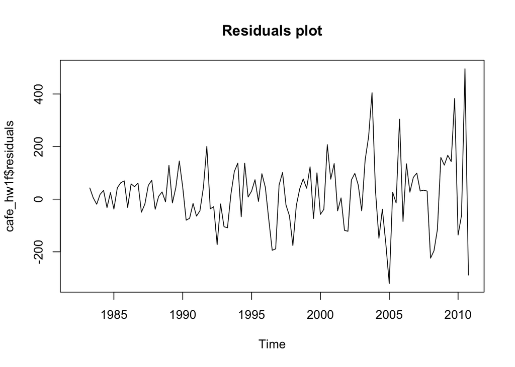

```r
cafe_hw1f <- forecast(cafe_hw1)
plot(cafe_hw1f$residuals, main = "Residuals plot")
```

- The residuals seem to have an increasing trend as the time passes.
- This shouldn’t be the case as the residuals need to be unpredictable for the forecast to be a good fit.

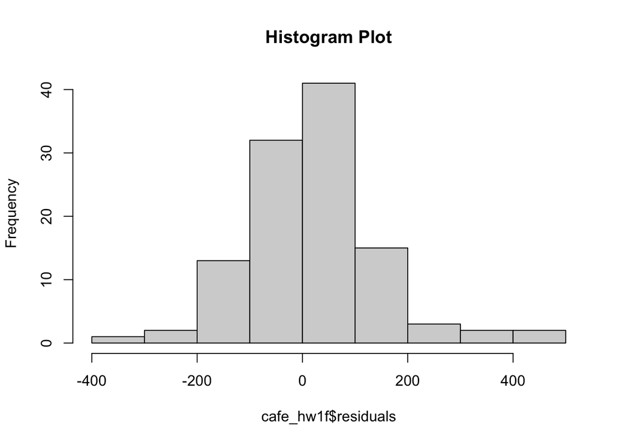

```r
hist(cafe_hw1f$residuals, main = "Histogram Plot")
```

- The plot ideally should be a perfect normal distribution contentrated at zero.
- In this case, the plot is not a perfect normal distribution stating the forecast to be wrong.

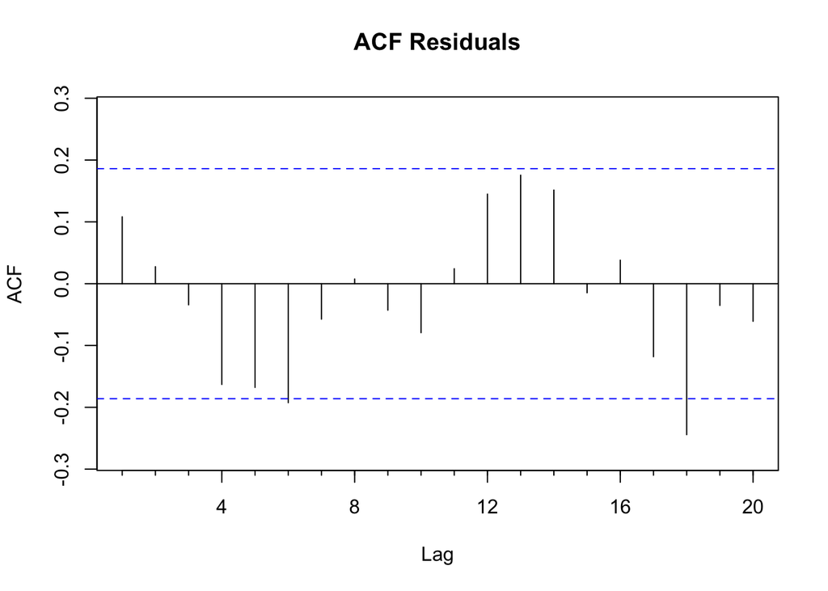

```r
Acf(cafe_hw1f$residuals, main = "ACF Residuals")
```

- Around 3 lines almost reached the confidence internal line.
- Two lines have crossed the confidence internal - meaning there is significant difference and the residuals can be predictable.

```r
accuracy(cafe_hw1f)
```

```
##                    ME     RMSE      MAE       MPE    MAPE      MASE      ACF1
## Training set 18.31246 126.9388 92.44294 0.4770665 2.47209 0.3363688 0.1081804
```

- The ME and RMSE are extremely high as expected.
- For the forecast to be the best, the RMSE should be the least.
- As the results from above histogram, ACF suggested, the accuracy test justified that the Holt-Winters forecast is not the right fit in this case.

## Exponential Smoothing Curves - Testing Additive, Multiplicative, and Damped

```r
#Additive
cafe_hw101 <- hw(cafe, seasonal = "additive")
summary(cafe_hw101)
```

```
##
## Forecast method: Holt-Winters' additive method
##
## Model Information:
## Holt-Winters' additive method
##
## Call:
##  hw(y = cafe, seasonal = "additive")
##
##   Smoothing parameters:
##     alpha = 0.8019
##     beta  = 0.0348
##     gamma = 0.1981
##
##   Initial states:
##     l = 1015.1428
##     b = 66.8533
##     s = -82.0018 196.8048 -38.0537 -76.7493
##
##   sigma:  131.8475
##
##      AIC     AICc      BIC
## 1678.154 1679.868 1702.858
##
## Error measures:
##                  ME     RMSE      MAE        MPE     MAPE      MASE      ACF1
## Training set 7.7748 127.1788 93.90854 -0.2234159 2.840862 0.3417017 0.1112598
##
## Forecasts:
##         Point Forecast    Lo 80    Hi 80    Lo 95    Hi 95
## 2011 Q1       7973.388 7804.419 8142.358 7714.972 8231.804
## 2011 Q2       8181.531 7961.218 8401.844 7844.591 8518.470
## 2011 Q3       8495.173 8230.174 8760.171 8089.892 8900.453
## 2011 Q4       8818.523 8512.453 9124.594 8350.429 9286.618
## 2012 Q1       8365.412 8003.828 8726.995 7812.417 8918.406
## 2012 Q2       8573.554 8176.134 8970.975 7965.752 9181.356
## 2012 Q3       8887.196 8454.623 9319.770 8225.632 9548.761
## 2012 Q4       9210.547 8743.275 9677.818 8495.917 9925.177
```

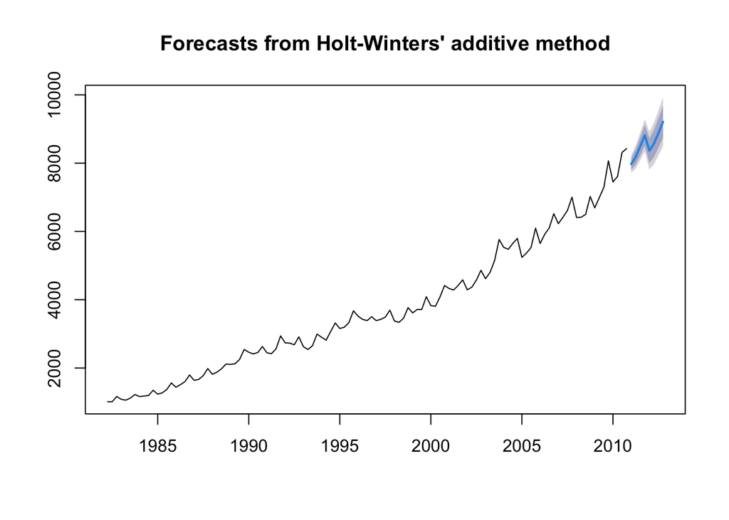

```r
plot(cafe_hw101)
```

```r
#Multiplicative
cafe_hw102 <- hw(cafe, seasonal = "multiplicative")
summary(cafe_hw102)
```

```
##
## Forecast method: Holt-Winters' multiplicative method
##
## Model Information:
## Holt-Winters' multiplicative method
##
## Call:
##  hw(y = cafe, seasonal = "multiplicative")
##
##   Smoothing parameters:
##     alpha = 0.8291
##     beta  = 0.0305
##     gamma = 0.1709
##
##   Initial states:
##     l = 1011.0139
##     b = 44.6412
##     s = 0.9873 1.0826 0.9753 0.9548
##
##   sigma:  0.0303
##
##      AIC     AICc      BIC
## 1607.042 1608.757 1631.747
##
## Error measures:
##                    ME     RMSE      MAE       MPE     MAPE      MASE      ACF1
## Training set 12.44773 122.9909 86.24199 0.1076133 2.338787 0.3138056 0.1027912
##
## Forecasts:
##         Point Forecast    Lo 80     Hi 80    Lo 95     Hi 95
## 2011 Q1       7901.830 7595.393  8208.266 7433.176  8370.483
## 2011 Q2       8083.490 7671.969  8495.011 7454.123  8712.857
## 2011 Q3       8378.617 7866.650  8890.584 7595.631  9161.603
## 2011 Q4       8810.984 8192.310  9429.659 7864.803  9757.166
## 2012 Q1       8256.936 7581.328  8932.543 7223.683  9290.188
## 2012 Q2       8442.750 7687.481  9198.019 7287.666  9597.834
## 2012 Q3       8746.930 7900.412  9593.447 7452.293 10041.566
## 2012 Q4       9194.121 8239.271 10148.971 7733.804 10654.438
```

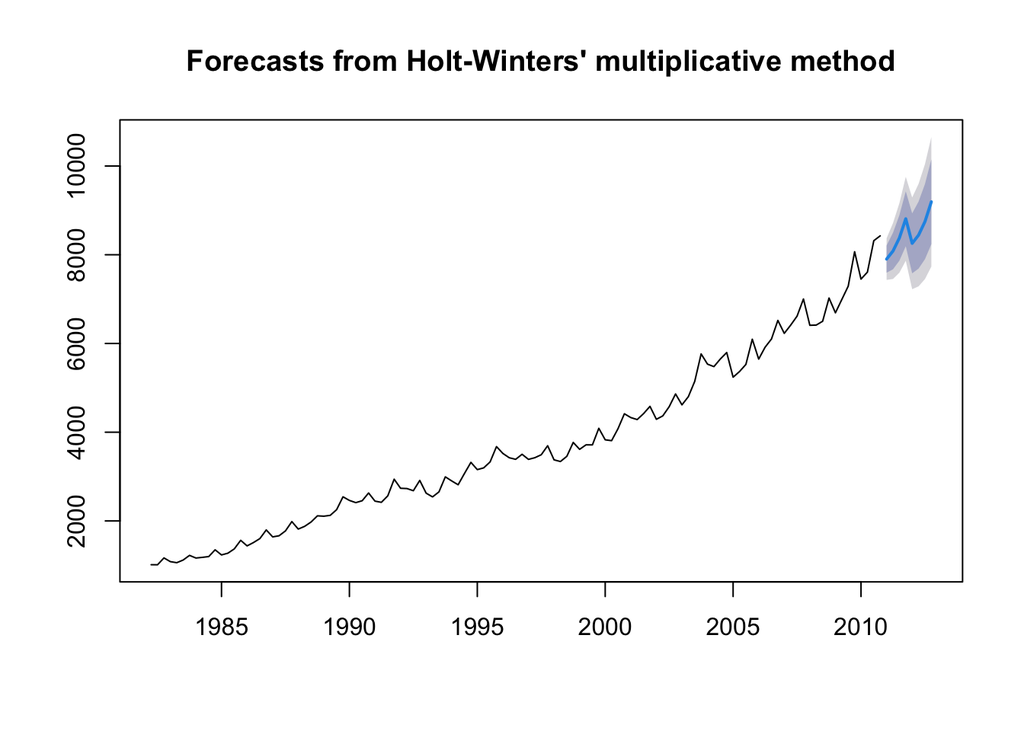

```r
plot(cafe_hw102)
```

```r
#Damped+Multiplicative
cafe_hw103 <- hw(cafe, damped = TRUE, seasonal = "multiplicative")
summary(cafe_hw103)
```

```
##
## Forecast method: Damped Holt-Winters' multiplicative method
##
## Model Information:
## Damped Holt-Winters' multiplicative method
##
## Call:
##  hw(y = cafe, seasonal = "multiplicative", damped = TRUE)
##
##   Smoothing parameters:
##     alpha = 0.835
##     beta  = 0.0629
##     gamma = 0.165
##     phi   = 0.98
##
##   Initial states:
##     l = 1010.2634
##     b = 53.377
##     s = 0.9857 1.0846 0.975 0.9547
##
##   sigma:  0.0313
##
##      AIC     AICc      BIC
## 1615.084 1617.200 1642.533
##
## Error measures:
##                    ME    RMSE     MAE       MPE     MAPE      MASE      ACF1
## Training set 18.86993 125.112 88.7826 0.3361294 2.412139 0.3230501 0.0866073
##
## Forecasts:
##         Point Forecast    Lo 80     Hi 80    Lo 95     Hi 95
## 2011 Q1       7904.871 7587.946  8221.796 7420.177  8389.566
## 2011 Q2       8087.235 7653.517  8520.954 7423.920  8750.551
## 2011 Q3       8375.840 7826.838  8924.842 7536.213  9215.467
## 2011 Q4       8803.286 8128.776  9477.797 7771.711  9834.861
## 2012 Q1       8246.094 7499.577  8992.612 7104.394  9387.795
## 2012 Q2       8425.644 7579.418  9271.870 7131.453  9719.834
## 2012 Q3       8715.712 7755.423  9676.001 7247.076 10184.347
## 2012 Q4       9149.798 8053.569 10246.027 7473.261 10826.336
```

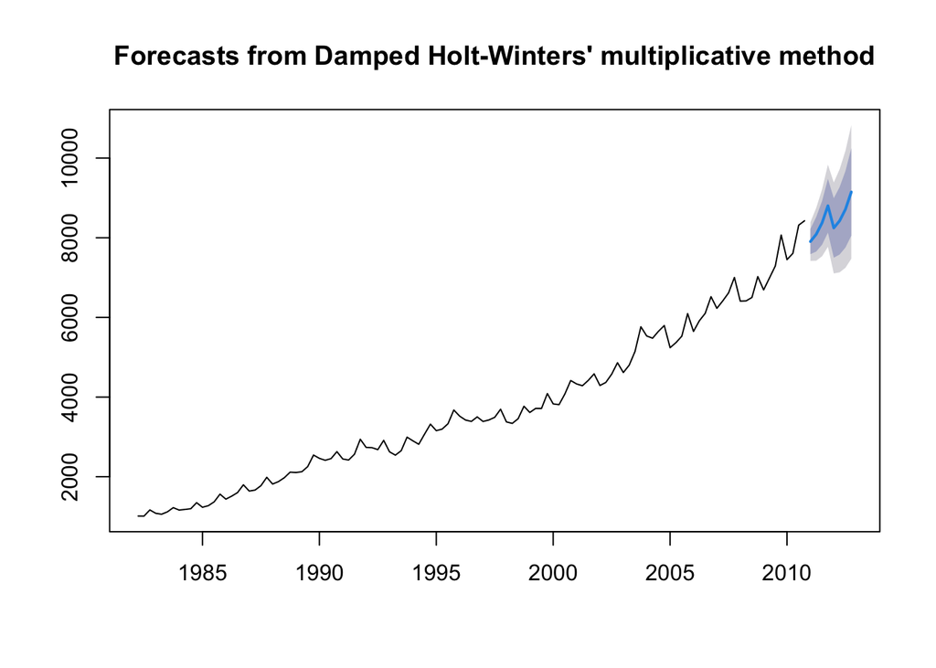

```r
plot(cafe_hw103)
```

- The hw functions for additive, multiplicative, and damped multiplicative are tested.
- Out of all the three, Multiplicative graph has a better RMSE. But, even that is above 122 suggesting it not be a good fit.

**Summary**

- As discussed in the class, Holt-Winters works well only if the data is a combination of Trend and Seasonal time series.
- In this case, the data showed only the characteristics of a Trend time series and not a Seasonal time series.
- Out of the hw functions, Multiplicative forecast showed the best results compared to the other two.